# Kaggle - House Prices

Step 3: Data Modeling

Gimme the Prize

2020-01-24

My plan is to fit a simple linear regression model, then try several subsetting and regularization models (stepwise selection, ridge, lasso, elastic net), and then tree-based models (bagged, random forest, and boosting).

# Setup

Load the libraries, and the data sets produced in the prior step.

```r
library(tidyverse)
library(caret)  # for machine learning workflow
#library(broom)
library(e1071)  # for skewness
library(recipes)

d.train <- readRDS(file = "./ames_02_train.RDS")
d.test <- readRDS(file = "./ames_02_test.RDS")
```

# Linear Regression

All linear models are of the form

$$y = \beta X + \epsilon$$

and estimate the $\beta$ coefficients by minimizing the sum of squared errors, or minimizing a function of the squared errors.

Linear models are relatively easy to interpret, and can be used for inferential analysis. A good framework for thinking about the various linear models is how they handle the bias-variance trade-off. Ordinary least squares (OLS) estimates *minimize bias*. Subsetting and regularization models introduce some bias in order to *reduce variance*.

## OLS

I’ll start with OLS regression as a benchmark model. OLS regression estimates the model coefficients by minimizing the sum of squared errors,

$$SSE = \sum{(y_i - \hat{y}_i)^2}.$$

The solution is $\hat{\beta} = (X'X)^{-1}X'y$. The OLS model is the best linear unbiased estimator if the residuals are independent random variables, normally distributed with mean zero and constant variance.

I’ll need to validate the model assumptions. I’ll also be wary of multicollinearity and near-zero variance (NZV) predictors. A unique inverse $(X'X)^{-1}$ only exists when there is no perfect multicollinearity and the matrix is of full rank, but even when predictors are only *highly* correlated, the regression coefficient estimations will still be unstable and can produce a poorly performing model.

Predictive models are also vulnerable to near-zero variance (NZV) predictors. NZV predictors contain little information, so they usually do not add much value to a linear regression. When cross-validating a model, NZV predictors can devolve into zero-variance predictors in the individual folds and break the model.

I’ll start by addressing NZV. I’ll collapse factor levels so that there are less NZV predictors after they are coded into dummies. This is more or less trial and error with the aid of the box-plots and anova post-hoc testing from the exploratory phase. The collapsing choices below improved the out-of-sample RMSE.

```r
d <- bind_rows(d.train, d.test)

d_lin <- d %>%
  mutate(Alley = fct_lump(Alley, n = 1)) %>%
  mutate(BldgType = fct_recode(BldgType, T_1 = "TwnhsE", T_1 = "1Fam", D_T_2 = "2fmCon", D_T_2 = "Duplex", D_T_2 = "Twnhs")) %>%
  mutate(BsmtFinType1 = fct_recode(BsmtFinType1, Rec2BLQ = "Rec", Rec2BLQ = "BLQ", LwQALQ = "LwQ", LwQALQ = "ALQ")) %>%
  mutate(BsmtFinType1 = fct_relevel(BsmtFinType1, "NA", "Rec2BLQ", "LwQALQ", "Unf", "GLQ")) %>%
  mutate(BsmtFinType2 = fct_recode(BsmtFinType2, Rec2BLQ = "Rec", Rec2BLQ = "BLQ", LwQALQ = "LwQ", LwQALQ = "ALQ")) %>%
  mutate(BsmtFinType2 = fct_relevel(BsmtFinType2, "NA", "Rec2BLQ", "LwQALQ", "Unf", "GLQ")) %>%
  mutate(BsmtQual = fct_drop(BsmtQual)) %>%
  mutate(Electrical = fct_recode(Electrical, Other = "FuseP", Other = "FuseF", Other = "FuseA", Other = "Mix")) %>%
  mutate(ExterCond = fct_recode(ExterCond, Po_Fa = "Po", Po_Fa = "Fa", Ta_Ex = "TA", Ta_Ex = "Gd", Ta_Ex = "Ex")) %>%
  mutate(Exterior1st = fct_recode(Exterior1st, VinalSdP = "VinylSd", VinalSdP = "Stone", VinalSdP = "ImStucc",
                                  HdBoardP = "HdBoard", HdBoardP = "CBlock", HdBoardP = "AsphShn", HdBoardP = "BrkComm")) %>%
  mutate(Exterior2nd = fct_recode(Exterior2nd, WdSdngP = "Wd Sdng", WdSdngP = "WdShing", WdSdngP = "Stucco",
                                  HdBoardP = "HdBoard", HdBoardP = "ImStucc")) %>%
  mutate(ExterQual = fct_recode(ExterQual, Fa_TA = "Fa", Fa_TA = "TA")) %>%
  mutate(Fence = fct_recode(Fence, NA_GP = "NA", NA_GP = "GdPrv",
                            M_M_G = "MnWw", M_M_G = "MnPrv", M_M_G = "GdWo")) %>%
  mutate(FireplaceQu = fct_recode(FireplaceQu, NA_Fa = "NA", NA_Fa = "Po", NA_Fa = "Fa")) %>%
  mutate(Foundation = fct_recode(Foundation, CBlockP = "CBlock", CBlockP = "Stone")) %>%
  mutate(Functional = fct_lump(Functional, n = 1)) %>%
  mutate(GarageCond = fct_recode(GarageCond, NA_Fa = "NA", NA_Fa = "Po", NA_Fa = "Fa",
                                 TA_Ex = "TA", TA_Ex = "Gd", TA_Ex = "Ex")) %>%
  mutate(GarageFinish = fct_recode(GarageFinish, NA_Unf = "NA", NA_Unf = "Unf")) %>%
  mutate(GarageQual = fct_recode(GarageQual, Po_Fa = "Po", Po_Fa = "Fa", Gd_Ex = "Gd", Gd_Ex = "Ex")) %>%
  mutate(GarageType = fct_recode(GarageType, CarPortP = "CarPort", CarPortP = "NA")) %>%
  mutate(Heating = fct_lump(Heating, n = 1)) %>%
  mutate(HouseStyle = fct_recode(HouseStyle, Story2P = "2Story", Story2P = "2.5Fin")) %>%
  mutate(LandContour = fct_lump(LandContour, n = 1)) %>%
  mutate(LandSlope = fct_lump(LandSlope, n = 1)) %>%
  mutate(LotShape = fct_recode(LotShape, IR = "IR1", IR = "IR2", IR = "IR3")) %>%
  mutate(MiscFeature = fct_lump(MiscFeature, n = 1)) %>%
  mutate(MSZoning = fct_recode(MSZoning, C_P = "C", C_P = "RH", C_P = "RM")) %>%
  mutate(Neighborhood = fct_recode(Neighborhood, A1 = "NoRidge", A1 = "NridgHt", A1 = "StoneBr",
                                   A2 = "Veenker", A2 = "Timber", A2 = "Somerst", A2 = "ClearCr",
                                   A3 = "Crawfor", A3 = "CollgCr", A3 = "Gilbert",
                                   A4 = "NWAmes", A4 = "Blmngtn", A4 = "SawyerW",
                                   A5 = "NAmes", A5 = "NPkVill", A5 = "Blueste", A5 = "Sawyer", A5 = "SWISU", A5 = "Mitchel",
                                   A6 = "OldTown", A6 = "BrkSide", A6 = "Edwards", A6 = "BrDale", A6 = "MeadowV", A6 = "IDOTRR")) %>%
  dplyr::select(-SalePrice, -Condition1, -Condition2, -CondRoad, -CondRail, -CondPos)

d_lin_test <- d_lin[is.na(d_lin$logSalePrice), ]
d_lin_train <- d_lin[!is.na(d_lin$logSalePrice), ]
```

Further split the training data 80:20 into `d_lin_train80` (n = 1,161) and `d_lin_train20` (n = 289). I’ll use `d_lin_train80` for tuning, estimating coefficients, and estimating performance, and `d_lin_train20` to compare the resulting models. `createDataPartition()` ensures the distribution of the response variable is similar in the two distributions.

```r
set.seed(12345)
partition <- createDataPartition(d_lin_train$logSalePrice, p = 0.80, list = FALSE)
d_lin_train80 <- d_lin_train[partition, ]
d_lin_train20 <- d_lin_train[-partition, ]
```

A common training control object will ensure each model is generated under similar conditions. I will use 10-fold cross-validation. `createFolds()` creates folds with similar distributions of the target variable.

```r
model.trControl <- trainControl(
  method = "cv",
  # specify the 10 folds instead of n = 10
  index = createFolds(
    d_lin_train80$logSalePrice,
    k = 10,
    returnTrain = TRUE
    ),
  verboseIter = FALSE,  # print results to log?
  # save predictions for optimal tuning params
  savePredictions = "final"
  )
```

Create a recipe object to contol preprocessing. Here is the basic recipe. I’ll add to it in pieces.

```r
ols_recipe <- d_lin_train80 %>%
  recipe(logSalePrice ~ .) %>%
  update_role(Id, new_role = "ID")
```

```r
ols_recipe_2 <- ols_recipe %>%
  step_dummy(all_nominal())
ols_baked_2 <- ols_recipe_2 %>% prep(d_lin_train80) %>% bake(d_lin_train80)
ols_baked_2 %>% names() %>% length() - 2
```

```
## [1] 220
```

Remove the NZVs. I’ll use the `nearZeroVar` default thresholds to identify NZVs: ratio of most common to second most common variable >= 95/5, and percentage of unique values <10%.

```r
nearZeroVar(ols_baked_2, saveMetrics = TRUE) %>%
  rownames_to_column(var = "predictor") %>%
  filter(nzv == TRUE)
```

```
##                predictor  freqRatio percentUnique zeroVar  nzv
## 1          EnclosedPorch   90.36364    8.95779500   FALSE TRUE
## 2           KitchenAbvGr   21.28846    0.25839793   FALSE TRUE
## 3           LowQualFinSF  570.00000    1.72265289   FALSE TRUE
## 4                MiscVal  124.55556    1.46425495   FALSE TRUE
## 5               PoolArea 1156.00000    0.51679587   FALSE TRUE
## 6            ScreenPorch  214.20000    5.77088717   FALSE TRUE
## 7             X3SsnPorch  570.50000    1.63652024   FALSE TRUE
## 8             BsmtCond_1   21.81250    0.43066322   FALSE TRUE
## 9             BsmtCond_2   22.12245    0.43066322   FALSE TRUE
## 10            BsmtCond_3   21.81250    0.43066322   FALSE TRUE
## 11            BsmtCond_4   22.12245    0.43066322   FALSE TRUE
## 12            BsmtCond_5   21.81250    0.43066322   FALSE TRUE
## 13           ExterCond_1   49.47826    0.17226529   FALSE TRUE
## 14   Exterior1st_BrkFace   28.76923    0.17226529   FALSE TRUE
```

[output cut: 80 more lines]

```r
ols_recipe_3 <- ols_recipe_2 %>%
  step_nzv(all_predictors())
ols_baked_3 <- ols_recipe_3 %>% prep(d_lin_train80) %>% bake(d_lin_train80)
ols_baked_3 %>% names() %>% length() - 2
```

```
## [1] 126
```

```r
lin_combos <- findLinearCombos(ols_baked_3)
map(lin_combos$linearCombos, function(x) colnames(ols_baked_3)[x])
```

```
## [[1]]
## [1] "TotalBath"    "BsmtFullBath" "BsmtHalfBath" "FullBath"
## [5] "HalfBath"
##
## [[2]]
## [1] "TotalBsmtSF" "BsmtFinSF1"  "BsmtFinSF2"  "BsmtUnfSF"
##
## [[3]]
## [1] "TotalSF"    "BsmtFinSF1" "BsmtFinSF2" "BsmtUnfSF"  "GrLivArea"
##
## [[4]]
## [1] "BsmtQual_4"     "BsmtFinType1_1" "BsmtFinType1_2" "BsmtFinType1_3"
## [5] "BsmtFinType1_4" "BsmtQual_1"     "BsmtQual_2"     "BsmtQual_3"
##
## [[5]]
## [1] "HasAlley_X1" "Alley_Other"
##
## [[6]]
## [1] "IsFunctional_X1" "Functional_1"    "GarageQual_1"    "GarageQual_2"
## [5] "GarageQual_3"    "HasGarage_X1"
##
## [[7]]
## [1] "KitchenQual_4" "GarageQual_1"  "GarageQual_2"  "GarageQual_3"
## [5] "HasGarage_X1"  "KitchenQual_1" "KitchenQual_2" "KitchenQual_3"
##
## [[8]]
## [1] "LvlLand_X1"        "GarageQual_1"      "GarageQual_2"
## [4] "GarageQual_3"      "HasGarage_X1"      "LandContour_Other"
```

```r
colnames(ols_baked_3)[lin_combos$remove]
```

```
## [1] "TotalBath"       "TotalBsmtSF"     "TotalSF"         "BsmtQual_4"
## [5] "HasAlley_X1"     "IsFunctional_X1" "KitchenQual_4"   "LvlLand_X1"
```

```r
ols_recipe_4 <- ols_recipe_3 %>%
  step_lincomb(all_numeric(), -all_outcomes())
ols_baked_4 <- ols_recipe_4 %>% prep(d_lin_train80) %>% bake(d_lin_train80)
ols_baked_4 %>% names() %>% length() - 2
```

```
## [1] 118
```

```r
cor_vars <- findCorrelation(cor(ols_baked_4))
colnames(ols_baked_4)[cor_vars]
```

```
## [1] "Exterior2nd_VinylSd" "HasGarage_X1"        "HeatingQC_2"
## [4] "RoofStyle_Hip"       "SaleType_New"        "Exterior1st_MetalSd"
## [7] "GarageQual_1"        "GarageType_CarPortP" "HouseStyle_X1.5Fin"
```

```r
ols_recipe_5 <- ols_recipe_4 %>%
  step_corr(all_numeric(), -all_outcomes(), threshold = .90)
ols_baked_5 <- ols_recipe_5 %>% prep(d_lin_train80) %>% bake(d_lin_train80)
ols_baked_5 %>% names() %>% length() - 2
```

```
## [1] 109
```

```r
col_is_num <- map(d_lin_train80, ~ class(.x)[1] %in% c("integer", "numeric")) %>% unlist()
col_skew <- map(d_lin_train80[, col_is_num], skewness) %>% unlist()
data.frame(var = names(col_skew), skew = col_skew) %>%
  filter(abs(skew) > 0.5) %>%
  arrange(-abs(skew))
```

```
##              var       skew
## 1        MiscVal 22.2711222
## 2       PoolArea 15.5914262
## 3     X3SsnPorch  9.9831088
## 4   LowQualFinSF  8.6658129
## 5   KitchenAbvGr  4.6743843
## 6     BsmtFinSF2  4.3543305
## 7    ScreenPorch  4.0566740
## 8   BsmtHalfBath  4.0195759
## 9        LotArea  3.9375413
## 10 EnclosedPorch  3.0302183
## 11    MasVnrArea  2.6578284
## 12   LotFrontage  2.2013745
## 13   OpenPorchSF  2.0418108
## 14    WoodDeckSF  1.4641466
## 15  YearRemodAdd -1.0511950
## 16   GarageYrBlt -0.9840840
## 17     BsmtUnfSF  0.9201079
## 18     GrLivArea  0.7735131
## 19     X1stFlrSF  0.7582925
## 20     X2ndFlrSF  0.7538169
## 21    BsmtFinSF1  0.7346855
## 22   OverallCond  0.6974123
## 23      HalfBath  0.6643709
## 24  TotRmsAbvGrd  0.6508043
## 25 AbvGrdSFperRm  0.6455908
## 26    Fireplaces  0.6324079
## 27     YearBuilt -0.6243084
## 28       TotalSF  0.5995599
## 29  BsmtFullBath  0.5336775
```

Box-Cox will only transform the strictly positive variables.

```r
boxcox_vars <- preProcess(as.data.frame(ols_baked_5), method = "BoxCox")
boxcox_vars$bc %>% names() %>% setdiff(c("Id", "logSalePrice"))
```

```
##  [1] "AbvGrdSFperRm" "GarageYrBlt"   "GrLivArea"     "LotArea"
##  [5] "LotFrontage"   "OverallCond"   "OverallQual"   "TotRmsAbvGrd"
##  [9] "X1stFlrSF"     "YearBuilt"     "YearRemodAdd"  "YrSold"
```

```r
ols_recipe_6 <- ols_recipe_5 %>%
  step_BoxCox(all_numeric(), -all_outcomes())
ols_baked_6 <- ols_recipe_6 %>% prep(d_lin_train80) %>% bake(d_lin_train80)
```

Centering and scaling the data will not affect the model performance, but it provides a useful way to compare the predictor effects on the response.

```r
ols_recipe_7 <- ols_recipe_6 %>%
  step_center(all_predictors(), -all_nominal()) %>%
  step_scale(all_predictors(), -all_nominal())
```

Now train the model.

```r
model.lm <- train(
  x = ols_recipe_7,
  data = d_lin_train80,
  method = "lm",
  metric = "RMSE",
  trControl = model.trControl
)
```

What did I get for a model?

```r
summary(model.lm)
```

```
##
## Call:
## lm(formula = .outcome ~ ., data = dat)
##
## Residuals:
##      Min       1Q   Median       3Q      Max
## -0.73876 -0.04804  0.00399  0.05117  0.43340
##
## Coefficients:
##                         Estimate Std. Error  t value Pr(>|t|)
## (Intercept)           12.0214216  0.0031426 3825.283  < 2e-16 ***
## AbvGrdSFperRm          0.0516609  0.0615264    0.840 0.401293
## BedroomAbvGr          -0.0087206  0.0053971   -1.616 0.106434
## BsmtFinSF1             0.0579219  0.0103616    5.590 2.89e-08 ***
## BsmtFinSF2             0.0226156  0.0063908    3.539 0.000420 ***
## BsmtFullBath           0.0164188  0.0050044    3.281 0.001069 **
## BsmtHalfBath           0.0008223  0.0035156    0.234 0.815111
## BsmtUnfSF              0.0359589  0.0093729    3.836 0.000132 ***
## Fireplaces             0.0146022  0.0063029    2.317 0.020709 *
## FullBath               0.0062161  0.0060026    1.036 0.300643
## GarageArea             0.0097182  0.0080907    1.201 0.229958
## GarageCars             0.0212746  0.0082239    2.587 0.009817 **
## GarageYrBlt           -0.0038350  0.0086030   -0.446 0.655854
## GrLivArea             -0.0058740  0.1131178   -0.052 0.958596
## HalfBath               0.0094760  0.0051493    1.840 0.066013 .
## LotArea                0.0278173  0.0057114    4.871 1.28e-06 ***
## LotFrontage            0.0077915  0.0053581    1.454 0.146201
## MasVnrArea             0.0019613  0.0050702    0.387 0.698958
## OpenPorchSF            0.0077223  0.0037997    2.032 0.042369 *
## OverallCond            0.0501424  0.0043824   11.442  < 2e-16 ***
## OverallQual            0.0651181  0.0065853    9.888  < 2e-16 ***
## TotRmsAbvGrd           0.0714772  0.0833612    0.857 0.391397
## WoodDeckSF             0.0083414  0.0036146    2.308 0.021209 *
## X1stFlrSF              0.0435992  0.0156987    2.777 0.005580 **
## X2ndFlrSF              0.0535772  0.0158569    3.379 0.000755 ***
## YearBuilt              0.0440373  0.0102429    4.299 1.87e-05 ***
## YearRemodAdd           0.0175452  0.0052391    3.349 0.000840 ***
## YrSold                -0.0063114  0.0034397   -1.835 0.066804 .
## Alley_Other           -0.0044231  0.0038104   -1.161 0.245984
## BldgType_D_T_2        -0.0139378  0.0041916   -3.325 0.000914 ***
```

[output cut: 71 more lines]

```
## Neighborhood_A5       -0.0072359  0.0063114   -1.146 0.251858
## Neighborhood_A6       -0.0204579  0.0073342   -2.789 0.005376 **
## Neighborhood_A2        0.0109429  0.0057842    1.892 0.058782 .
## Neighborhood_A3        0.0147286  0.0056825    2.592 0.009676 **
## Neighborhood_A1        0.0273242  0.0055029    4.965 7.99e-07 ***
## PavedDrive_N          -0.0042037  0.0039493   -1.064 0.287392
## RoofStyle_Gable        0.0007218  0.0036611    0.197 0.843753
## SaleCondition_Abnorml -0.0163731  0.0033662   -4.864 1.33e-06 ***
## SaleCondition_Partial  0.0162134  0.0039830    4.071 5.04e-05 ***
## ---
## Signif. codes:  0 '***' 0.001 '**' 0.01 '*' 0.05 '.' 0.1 ' ' 1
##
## Residual standard error: 0.1071 on 1051 degrees of freedom
## Multiple R-squared:  0.9333, Adjusted R-squared:  0.9264
## F-statistic:   135 on 109 and 1051 DF,  p-value: < 2.2e-16
```

lm warned “X not defined because of singularities” prior to collapsing some of the factor variables. No errors now. How did the model perform in terms of the within-sample RMSE?

```r
print(model.lm)
```

```
## Linear Regression
##
## 1161 samples
##   90 predictor
##
## Recipe steps: dummy, nzv, lincomb, corr, BoxCox, center, scale
## Resampling: Cross-Validated (10 fold)
## Summary of sample sizes: 1045, 1045, 1045, 1045, 1044, 1044, ...
## Resampling results:
##
##   RMSE      Rsquared   MAE
##   0.113489  0.9173264  0.07957126
##
## Tuning parameter 'intercept' was held constant at a value of TRUE
```

The within-sample RMSE was 0.1135. The within-sample RMSE is the average of 10 hold-out fold RMSEs, `mean(model.lm$resample$RMSE)`. Here are the results of the individual folds.

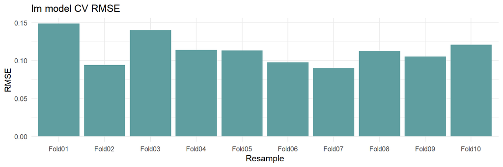

```r
model.lm$resample %>%
  ggplot(aes(x = Resample, y = RMSE)) +
  geom_col(fill = "cadetblue") +
  theme_minimal() +
  labs(title = "lm model CV RMSE")
```

Here is an observed vs predicted plot with prediction errors > 0.50 flagged.

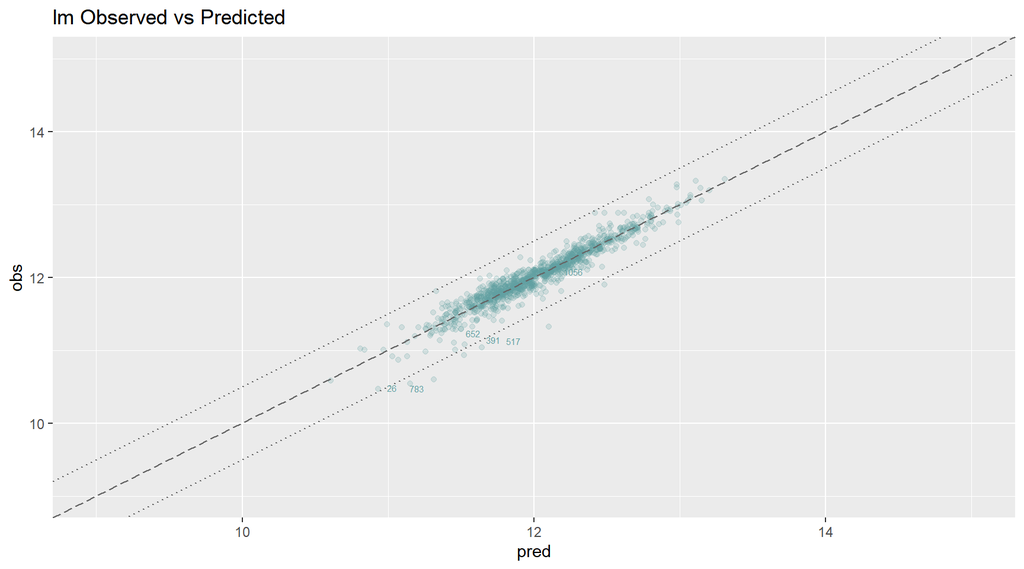

```r
model.lm$pred %>%
  mutate(label = ifelse(abs(obs - pred) > 0.50, rowIndex, "")) %>%
  ggplot(aes(x = pred, y = obs, label = label)) +
  geom_point(alpha = .2, color = "cadetblue") +
  geom_abline(slope = 1, intercept = 0, color = "grey40", linetype = "longdash") +
  geom_abline(slope = 1, intercept = -.50, color = "grey40", linetype = "dotted") +
  geom_abline(slope = 1, intercept = +.50, color = "grey40", linetype = "dotted") +
  geom_text(size = 2, color = "cadetblue", position = position_jitter(width = .3, height = .3)) +
  expand_limits(x = c(9, 15), y = c(9, 15)) +
  labs(title = "lm Observed vs Predicted")
```

Looks like the model makes the worst mistakes predicting the values of inexpensive houses, usually overestimating their sale price. Does the model conform to the linear model assumption that residuals are independent random variables normally distributed with mean zero and constant variance? A standardized residuals vs fits plot should vary around e=0 (linearity) with a constant width (especially no fan shape at the low or high ends) (equal variance). 95% of standardized residuals should fall within two standard deviations.

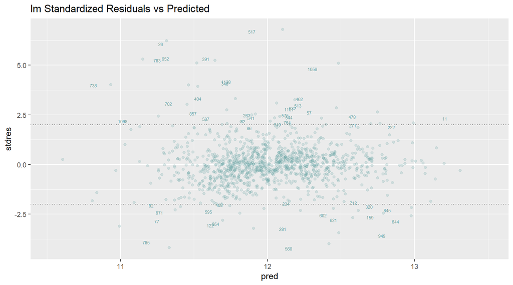

```r
model.lm$pred %>%
  mutate(res = pred-obs,
         stdres = res / sd(res),
         label = ifelse(abs(stdres) > 2, rowIndex, "")) %>%
  ggplot(aes(x = pred, y = stdres, label = label)) +
  geom_point(alpha = .2, color = "cadetblue") +
  geom_abline(slope = 0, intercept = 2, color = "grey40", linetype = "dotted") +
  geom_abline(slope = 0, intercept = -2, color = "grey40", linetype = "dotted") +
  geom_text(size = 2, position = position_jitter(width = .3, height = .3), color = "cadetblue") +
  labs(title = "lm Standardized Residuals vs Predicted")
```

A normal probability plot compares the theoretical percentiles of the normal distribution versus the observed sample percentiles. It should be approximately linear.

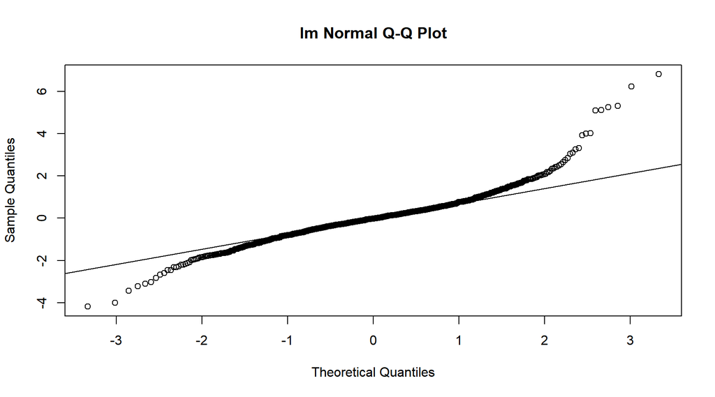

```r
stdres <- model.lm$pred %>%
  mutate(res = pred-obs,
         stdres = res / sd(res)) %>%
  pull(stdres)
qqnorm(stdres, main = "lm Normal Q-Q Plot")
qqline(stdres)
```

This one does not look so good. The distribution is heavy tailed. There are many extreme positive and negative residuals. The Anderson-Darling normality test p-value is the probability of calculating the test statistic if the distribution is normal. This one is not normal.

```r
model.lm$pred %>%
  mutate(res = pred-obs) %>%
  pull(res) %>%
  nortest::ad.test()
```

```
##
##  Anderson-Darling normality test
##
## data:  .
## A = 14.248, p-value < 2.2e-16
```

I’m not sure how to proceed here - use a different transformation for the response variable? I’m going to move on. Which predictors were both significant and meaningful? I standardized the predictors in the model, so I can compare the coefficients. The coefficient values indicate the effect of a 1 SD change in the predictor value on the log SalePrice. Here are the predictors with p-values <.05 and coefficient estimates > 0.01.

```r
summary(model.lm)$coefficients %>%
  data.frame() %>%
  rownames_to_column(var = "Variable") %>%
  mutate(p = `Pr...t..`) %>%
  filter(abs(Estimate) > .01 & p < .05 & Variable != "(Intercept)") %>%
  dplyr::select(Variable, Estimate, p) %>%
  arrange(desc(abs(Estimate))) %>%
  top_n(10, wt = Estimate)
```

```
##             Variable   Estimate            p
## 1        OverallQual 0.06511809 4.161327e-22
## 2         BsmtFinSF1 0.05792188 2.892602e-08
## 3          X2ndFlrSF 0.05357723 7.547640e-04
## 4        OverallCond 0.05014235 1.185449e-28
## 5          YearBuilt 0.04403732 1.872458e-05
## 6          X1stFlrSF 0.04359918 5.579669e-03
## 7  GarageType_Detchd 0.03807817 1.801799e-04
## 8          BsmtUnfSF 0.03595893 1.322349e-04
## 9  GarageType_Attchd 0.03077459 5.106513e-03
## 10           LotArea 0.02781731 1.284012e-06
```

Overall quality (no surprise), followed by basement size (a bit of a surprise), then second and first floor size. These all seem good. Another way to evaluate the model is with “variable importance”. For linear models, that is defined by the absolute value of the t-statistic.

```r
varImp(model.lm)
```

```
## lm variable importance
##
##   only 20 most important variables shown (out of 109)
##
##                       Overall
## OverallCond            100.00
## OverallQual             86.37
## BsmtFinSF1              48.67
## Functional_1            44.68
## Neighborhood_A1         43.19
## LotArea                 42.36
## SaleCondition_Abnorml   42.30
## YearBuilt               37.35
## SaleCondition_Partial   35.34
## GarageQual_2            33.51
## BsmtUnfSF               33.29
## GarageType_Detchd       32.60
## BsmtFinSF2              30.67
## MSZoning_C_P            29.57
## X2ndFlrSF               29.27
## YearRemodAdd            29.01
## BldgType_D_T_2          28.80
## BsmtFullBath            28.41
## LotConfig_CulDSac       28.29
## CentralAir_Y            26.93
```

Moving on, how does the model perform against the out-of-sample set?

```r
(perf.lm <- postResample(pred = predict(model.lm, newdata = d_lin_train20),
                         obs = d_lin_train20$logSalePrice))
```

```
##       RMSE   Rsquared        MAE
## 0.11200779 0.92011014 0.07650913
```

It’s slightly better than the within-sample RMSE. That’s surprising - I expected it to be a little worse. I’ll compare this performance with other models.

## Stepwise Selection

The more predictors that are included in the model, the smaller the within-sample RMSE. This does not guarantee better predictive performance out-of-sample though, because the model coefficients are less stable when they are correlated with each other. Stepwise selection iteratively adds and removes predictors in the model to find the subset of predictors that minimize the model prediction error.

```r
model.lmStepAIC <- train(
  x = ols_recipe_7,
  data = d_lin_train80,
  method = "lmStepAIC",
  trace = FALSE,
  metric = "RMSE",
  trControl = model.trControl
)
```

What did I get for a model?

```r
summary(model.lmStepAIC)
```

```
##
## Call:
## lm(formula = .outcome ~ BedroomAbvGr + BsmtFinSF1 + BsmtFinSF2 +
##     BsmtFullBath + BsmtUnfSF + Fireplaces + FullBath + GarageCars +
##     GrLivArea + HalfBath + LotArea + OpenPorchSF + WoodDeckSF +
##     X1stFlrSF + X2ndFlrSF + YearBuilt + YearRemodAdd + YrSold +
##     BldgType_D_T_2 + BsmtExposure_1 + BsmtExposure_3 + BsmtFinType1_1 +
##     BsmtFinType1_2 + BsmtFinType1_3 + BsmtFinType1_4 + BsmtFinType2_1 +
##     CentralAir_Y + Cond_1 + Cond_2 + Electrical_1 + Exterior1st_HdBoardP +
##     Exterior1st_Plywood + Exterior1st_Wd.Sdng + Exterior2nd_HdBoardP +
##     Exterior2nd_WdSdngP + FireplaceQu_3 + Foundation_PConc +
##     Functional_1 + GarageCond_1 + GarageQual_2 + GarageType_Attchd +
##     GarageType_BuiltIn + GarageType_Detchd + HeatingQC_1 + KitchenQual_1 +
##     KitchenQual_3 + LotConfig_CulDSac + MasVnrType_Stone + MoSold_X5 +
##     MoSold_X6 + MoSold_X7 + MSSubClass_X60 + MSZoning_C_P + MSZoning_RL +
##     Neighborhood_A5 + Neighborhood_A6 + Neighborhood_A2 + Neighborhood_A3 +
##     Neighborhood_A1 + OverallCond_1 + OverallCond_2 + OverallCond_5 +
##     OverallCond_6 + OverallCond_7 + OverallCond_8 + OverallQual_1 +
##     OverallQual_5 + SaleCondition_Abnorml + SaleCondition_Partial,
##     data = dat)
##
## Residuals:
##      Min       1Q   Median       3Q      Max
## -0.73257 -0.05087  0.00198  0.05584  0.45001
##
## Coefficients:
##                        Estimate Std. Error  t value Pr(>|t|)
## (Intercept)           12.021422   0.003068 3918.704  < 2e-16 ***
## BedroomAbvGr          -0.007651   0.004543   -1.684 0.092435 .
## BsmtFinSF1             0.058315   0.009270    6.291 4.56e-10 ***
## BsmtFinSF2             0.023061   0.004985    4.627 4.16e-06 ***
## BsmtFullBath           0.015929   0.004572    3.484 0.000513 ***
## BsmtUnfSF              0.034182   0.008527    4.009 6.52e-05 ***
## Fireplaces             0.017383   0.003933    4.420 1.09e-05 ***
## FullBath               0.008046   0.005601    1.437 0.151141
## GarageCars             0.027817   0.005459    5.096 4.09e-07 ***
## GrLivArea              0.079656   0.016495    4.829 1.57e-06 ***
## HalfBath               0.008045   0.004876    1.650 0.099229 .
## LotArea                0.030453   0.004739    6.425 1.96e-10 ***
## OpenPorchSF            0.008396   0.003607    2.327 0.020121 *
```

[output cut: 48 more lines]

```
## OverallCond_2          0.011063   0.005682    1.947 0.051773 .
## OverallCond_5          0.027633   0.008709    3.173 0.001552 **
## OverallCond_6         -0.027615   0.006637   -4.161 3.42e-05 ***
## OverallCond_7          0.023562   0.006769    3.481 0.000520 ***
## OverallCond_8         -0.014683   0.004704   -3.121 0.001848 **
## OverallQual_1          0.076082   0.006800   11.189  < 2e-16 ***
## OverallQual_5         -0.013535   0.004424   -3.060 0.002270 **
## SaleCondition_Abnorml -0.016990   0.003218   -5.279 1.56e-07 ***
## SaleCondition_Partial  0.017602   0.003769    4.671 3.38e-06 ***
## ---
## Signif. codes:  0 '***' 0.001 '**' 0.01 '*' 0.05 '.' 0.1 ' ' 1
##
## Residual standard error: 0.1045 on 1091 degrees of freedom
## Multiple R-squared:  0.9341, Adjusted R-squared:  0.9299
## F-statistic:   224 on 69 and 1091 DF,  p-value: < 2.2e-16
```

How did the model perform in terms of the within-sample RMSE?

```r
print(model.lmStepAIC)
```

```
## Linear Regression with Stepwise Selection
##
## 1161 samples
##   90 predictor
##
## Recipe steps: dummy, nzv, lincomb, corr, BoxCox, center, scale
## Resampling: Cross-Validated (10 fold)
## Summary of sample sizes: 1045, 1045, 1045, 1045, 1044, 1044, ...
## Resampling results:
##
##   RMSE       Rsquared   MAE
##   0.1118655  0.9198388  0.07892731
```

The within-sample RMSE was 0.1119. This is actually a skosh *better* than the OLS model. Here are the results of the individual folds.

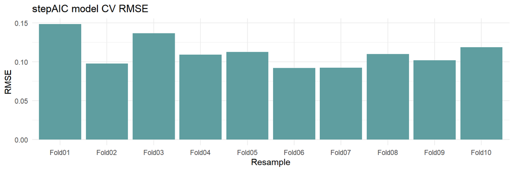

```r
model.lmStepAIC$resample %>%
  ggplot(aes(x = Resample, y = RMSE)) +
  geom_col(fill = "cadetblue") +
  theme_minimal() +
  labs(title = "stepAIC model CV RMSE")
```

Fold01 and Fold03 were the worst again. Here is the observed vs predicted plot with prediction errors > 0.50 flagged.

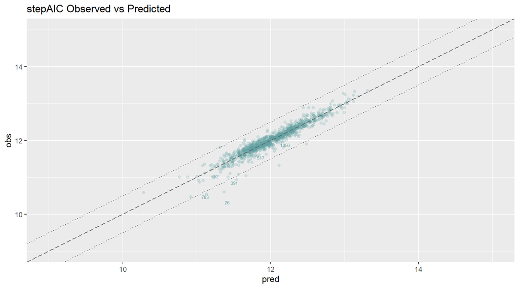

```r
model.lmStepAIC$pred %>%
  mutate(label = ifelse(abs(obs - pred) > 0.50, rowIndex, "")) %>%
  ggplot(aes(x = pred, y = obs, label = label)) +
  geom_point(alpha = .2, color = "cadetblue") +
  geom_abline(slope = 1, intercept = 0, color = "grey40", linetype = "longdash") +
  geom_abline(slope = 1, intercept = -.50, color = "grey40", linetype = "dotted") +
  geom_abline(slope = 1, intercept = +.50, color = "grey40", linetype = "dotted") +
  geom_text(size = 2, color = "cadetblue", position = position_jitter(width = .3, height = .3)) +
  expand_limits(x = c(9, 15), y = c(9, 15)) +
  labs(title = "stepAIC Observed vs Predicted")
```

Does the model conform to the linear model assumption that residuals are independent random variables normally distributed with mean zero and constant variance? Here is the standardized residuals vs fits plot.

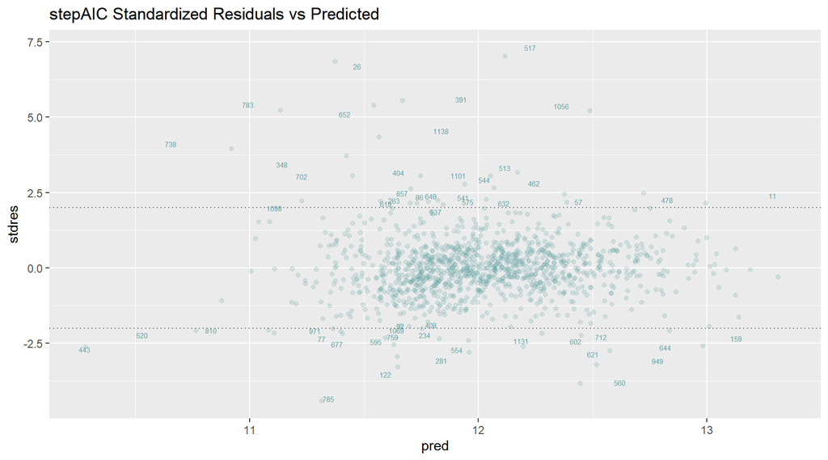

```r
model.lmStepAIC$pred %>%
  mutate(res = pred-obs,
         stdres = res / sd(res),
         label = ifelse(abs(stdres) > 2, rowIndex, "")) %>%
  ggplot(aes(x = pred, y = stdres, label = label)) +
  geom_point(alpha = .2, color = "cadetblue") +
  geom_abline(slope = 0, intercept = 2, color = "grey40", linetype = "dotted") +
  geom_abline(slope = 0, intercept = -2, color = "grey40", linetype = "dotted") +
  geom_text(size = 2, position = position_jitter(width = .3, height = .3), color = "cadetblue") +
  #  expand_limits(x = c(7.5, 15), y = c(7.5, 15)) +
  labs(title = "stepAIC Standardized Residuals vs Predicted")
```

Here is the normal probability plot.

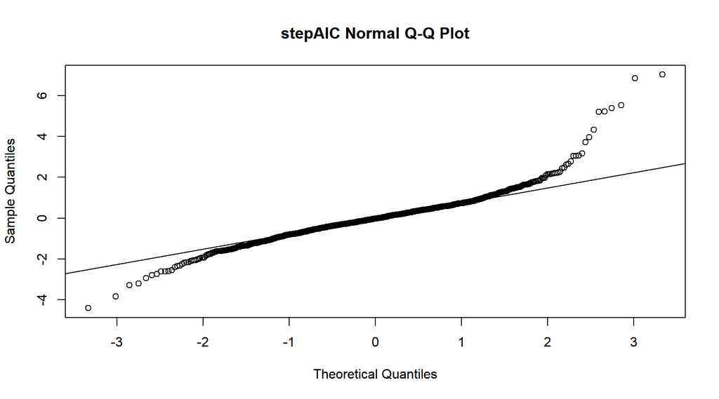

```r
stdres <- model.lmStepAIC$pred %>%
  mutate(res = pred-obs,
         stdres = res / sd(res)) %>%
  pull(stdres)
qqnorm(stdres, main = "stepAIC Normal Q-Q Plot")
qqline(stdres)
```

Not so good. The distribution is heavy tailed again. The Anderson-Darling normality test agrees.

```r
model.lmStepAIC$pred %>%
  mutate(res = pred-obs) %>%
  pull(res) %>%
  nortest::ad.test()
```

```
##
##  Anderson-Darling normality test
##
## data:  .
## A = 12.949, p-value < 2.2e-16
```

```r
summary(model.lmStepAIC)$coefficients %>%
  data.frame() %>%
  rownames_to_column(var = "Variable") %>%
  mutate(p = `Pr...t..`) %>%
  filter(abs(Estimate) > .01 & p < .05 & Variable != "(Intercept)") %>%
  dplyr::select(Variable, Estimate, p) %>%
  arrange(desc(abs(Estimate))) %>%
  top_n(10, wt = Estimate)
```

```
##             Variable   Estimate            p
## 1          GrLivArea 0.07965609 1.567464e-06
## 2      OverallQual_1 0.07608237 1.372706e-27
## 3         BsmtFinSF1 0.05831528 4.558297e-10
## 4          X2ndFlrSF 0.05647192 1.312983e-04
## 5          X1stFlrSF 0.05156739 6.794926e-05
## 6          YearBuilt 0.04970032 6.615414e-09
## 7      OverallCond_1 0.04461349 1.178710e-13
## 8  GarageType_Detchd 0.03831485 2.704818e-05
## 9          BsmtUnfSF 0.03418232 6.521129e-05
## 10 GarageType_Attchd 0.03408917 6.742738e-04
```

The top 10 predictors from `stepAIC` are nearly identical to those in `lm`, except for the introduction of `GrLivArea`. How about the variable importance?

```r
varImp(model.lmStepAIC)
```

```
## loess r-squared variable importance
##
##   only 20 most important variables shown (out of 122)
##
##                  Overall
## OverallQual_1     100.00
## GrLivArea          80.10
## GarageCars         69.98
## GarageArea         69.83
## ExterQual_1        69.14
## KitchenQual_1      67.50
## BsmtQual_1         63.75
## X1stFlrSF          57.77
## GarageYrBlt        54.34
## YearBuilt          52.87
## OverallQual_3      51.69
## FullBath           51.48
## GarageFinish_1     50.39
## KitchenQual_2      49.87
## ExterQual_3        49.51
## YearRemodAdd       47.96
## AbvGrdSFperRm      47.35
## TotRmsAbvGrd       43.80
## Foundation_PConc   42.54
## FireplaceQu_1      40.08
```

Similar to my “significant and meaningful” again. How does the model perform against the out-of-sample set?

```r
perf.step <- postResample(
  pred = predict(model.lmStepAIC, newdata = d_lin_train20),
  obs = d_lin_train20$logSalePrice
  )
perf.step
```

```
##       RMSE   Rsquared        MAE
## 0.11564600 0.91479381 0.07896297
```

Reassuringly, it’s slightly worse than the within-sample RMSE. It’s also about the same as the all-in OLS model I fit previously. And this model has only 69 predictors compared to 109 in the original model!

## Regularization Models

The collapsed factors that worked well for the simple OLS and stepwise selection models did not work so well here, so I’ll use the original data.

```r
d.train80 <- d.train[partition, !(colnames(d.train) %in% c("Id", "SalePrice"))]
d.train20 <- d.train[-partition, !(colnames(d.train) %in% c("Id", "SalePrice"))]
```

### Ridge

The Ridge approach estimates the linear model coefficients by minimizing an augmented loss fuction which includes a term, $\lambda$, that penalizes the magnitude of the coefficient estimates,

$$L_{ridge} = ||y - X \hat{\beta}||^2 + \lambda||\hat\beta||^2.$$

The resulting estimate for the coefficients is

$$\hat{\beta} = (X'X + \lambda I)^{-1}(X'Y).$$

As $\lambda \rightarrow 0$, ridge regression approaches OLS. The bias and variance for the ridge estimator is

$$Bias(\hat{\beta}_{ridge}) = -\lambda (X'X + \lambda I)^{-1} \beta$$

$$Var(\hat{\beta}_{OLS}) = \sigma^2(X'X + \lambda I)^{-1}X'X(X'X + \lambda I)^{-1}$$

The estimator bias increases with $\lambda$ and the estimator variance decreases with $\lambda$. The optimal level for $\lambda$ that balances the tradeoff is the one that minimizes some criterion with cross-validation, usually the root mean squared error (RMSE) (but you can also use the Akaike or Bayesian Information Criterion (AIC or BIC), or Rsquared).

Perform cross-validation to optimize $\lambda$, specifying `alpha = 0` in a tuning grid for ridge regression.

```r
# pen_recipe <-
#   recipe(logSalePrice ~ ., data = d.train80) %>%
#   step_zv(all_predictors()) %>%
#   step_center(all_predictors(), -all_nominal()) %>%
#   step_scale(all_predictors(), -all_nominal()) %>%
#   step_dummy(all_predictors(), -all_numeric())
```

```r
model.ridge <- train(
  logSalePrice ~ .,
#  x = pen_recipe,
  data = d.train80,
  method = "glmnet",
#  standardize = FALSE,
  metric = "RMSE",
  preProcess = c("zv", "center", "scale"),
  # tweak a tuning grid to zero in on best hyperparameter settings.
  tuneGrid = expand.grid(
    .alpha = 0,  # alpha = 0 for ridge regression
    .lambda = seq(0, 0.5, length = 100)),
  trControl = model.trControl
)
```

Here are the tuning results.

```r
model.ridge$bestTune
```

```
##    alpha    lambda
## 27     0 0.1313131
```

Here is a plot of the tuning process. I tweaked the tuning grid to hone in on the minimum lambda.

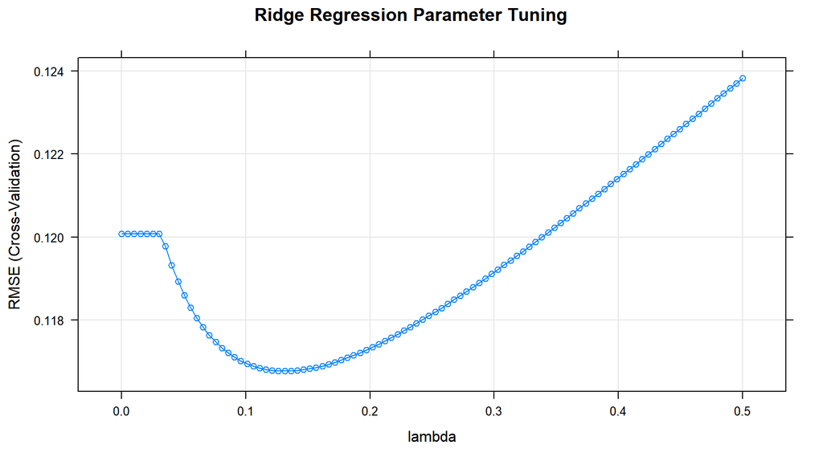

```r
plot(model.ridge, main = "Ridge Regression Parameter Tuning", xlab = "lambda")
```

What were the most important variables?

```r
varImp(model.ridge)
```

```
## glmnet variable importance
##
##   only 20 most important variables shown (out of 307)
##
##                      Overall
## OverallQual           100.00
## TotalSF                80.41
## GrLivArea              79.62
## OverallCond            75.43
## MSZoningC              66.82
## TotRmsAbvGrd           64.40
## X1stFlrSF              63.84
## AbvGrdSFperRm          54.97
## TotalBsmtSF            53.80
## YearRemodAdd           49.95
## LotArea                48.88
## BsmtFinSF1             47.96
## GarageArea             45.44
## GarageCars             42.01
## YearBuilt              41.30
## NeighborhoodStoneBr    40.77
## TotalBath              40.54
## SaleConditionAbnorml   40.10
## NeighborhoodCrawfor    39.54
## CentralAirY            39.19
```

How does the model perform against the out-of-sample set?

```r
(perf.ridge <- postResample(
  pred = predict(model.ridge, newdata = d.train20),
  obs = d.train20$logSalePrice
  ))
```

```
##       RMSE   Rsquared        MAE
## 0.10674369 0.92760838 0.07701126
```

Not bad. A new front-runner.

### Lasso

Lasso stands for “least absolute shrinkage and selection operator”. Like ridge, lasso adds a penalty for coefficients, but instead of penalizing the sum of squared coefficients (L2 penalty), lasso penalizes the sum of absolute values (L1 penalty). As a result, for high values of $\lambda$, coefficients can be zeroed under lasso.

The loss fuction for lasso is

$$L_{ridge} = ||y - X \hat{\beta}||^2 + \lambda||\hat\beta||.$$

```r
model.lasso <- train(
  logSalePrice ~ .,
  data = d.train80,
  method = "glmnet",
  metric = "RMSE",
  preProcess = c("zv", "center", "scale"),
  tuneGrid = expand.grid(
    .alpha = 1,  # alpha = 1 for lasso regression
    .lambda = seq(0, 0.025, length = 100)),
  trControl = model.trControl
)
```

Here are the tuning results.

```r
model.lasso$bestTune
```

```
##    alpha     lambda
## 20     1 0.00479798
```

Here is a plot of the tuning process for lambda.

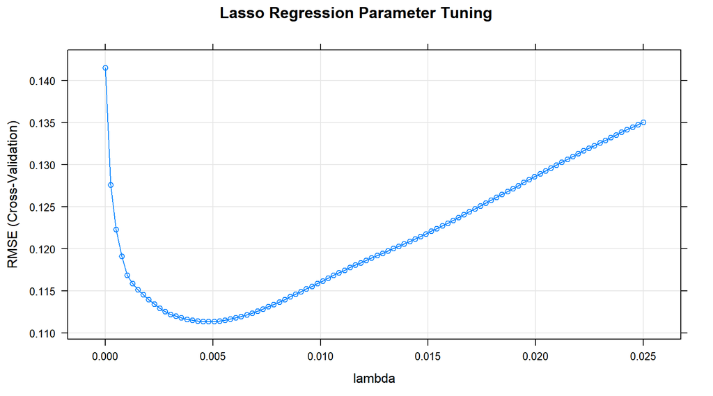

```r
plot(model.lasso, main = "Lasso Regression Parameter Tuning", xlab = "lambda")
```

What were the most important variables?

```r
varImp(model.lasso)
```

```
## glmnet variable importance
##
##   only 20 most important variables shown (out of 307)
##
##                      Overall
## TotalSF               100.00
## OverallQual            85.71
## GrLivArea              75.61
## YearBuilt              45.32
## OverallCond            42.07
## MSZoningC              32.64
## BsmtFinSF1             29.45
## LotArea                26.27
## GarageCars             21.99
## Functional.L           21.92
## YearRemodAdd           21.83
## GarageArea             19.60
## NeighborhoodCrawfor    18.97
## TotalBath              18.64
## MSZoningRM             18.26
## HeatingQC.L            17.46
## KitchenQual.Q          15.83
## SaleConditionPartial   15.73
## SaleConditionAbnorml   15.30
## CentralAirY            13.93
```

How does the model perform against the out-of-sample set?

```r
perf.lasso <- postResample(
  pred = predict(model.lasso, newdata = d.train20),
  obs = d.train20$logSalePrice)
perf.lasso
```

```
##       RMSE   Rsquared        MAE
## 0.10548266 0.92891834 0.07578788
```

Good. A new front-runner again.

### Elastic Net

Elastic Net combines the penalties of ridge and lasso to get the best of both worlds. The loss fuction for elastic net is

$$L_{enet} = \frac{||y - X \hat{\beta}||^2}{2n} + \lambda \frac{1 - \alpha}{2}||\hat\beta||^2 + \lambda \alpha||\hat\beta||.$$

In this loss function, new parameter $\alpha$ is a “mixing” parameter that balances the two approaches. You can see that if $\alpha$ is zero, you are back to ridge regression, and if $\alpha$ is one, you are back to lasso.

```r
model.elnet <- train(
  logSalePrice ~ .,
  data = d.train80,
  method = "glmnet",
  metric = "RMSE",
  preProcess = c("zv", "center", "scale"),
  tuneGrid = expand.grid(
    .alpha = seq(0, 0.25, length = 10),  # alpha varies for elastic net regression
    .lambda = seq(0, 0.05, length = 10)),
  trControl = model.trControl
)
```

Here are the tuning results.

```r
model.elnet$bestTune
```

```
##        alpha     lambda
## 56 0.1388889 0.02777778
```

Here is a plot of the tuning process. There are two hyperparameters this time: alpha and lambda.

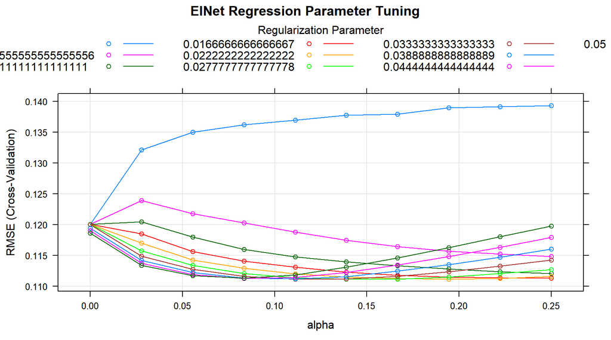

```r
plot(model.elnet, main = "ElNet Regression Parameter Tuning", xlab = "alpha")
```

What were the most important variables?

```r
varImp(model.elnet)
```

```
## glmnet variable importance
##
##   only 20 most important variables shown (out of 307)
##
##                      Overall
## OverallQual           100.00
## TotalSF                77.79
## GrLivArea              73.95
## OverallCond            52.79
## YearBuilt              44.93
## MSZoningC              44.25
## TotRmsAbvGrd           40.50
## BsmtFinSF1             35.46
## LotArea                34.43
## TotalBath              31.91
## Functional.L           30.04
## AbvGrdSFperRm          30.01
## YearRemodAdd           29.92
## GarageCars             28.58
## GarageArea             28.50
## NeighborhoodCrawfor    25.89
## MSZoningRM             24.16
## SaleConditionAbnorml   22.44
## TotalBsmtSF            21.26
## CentralAirY            20.77
```

How does the model perform against the out-of-sample set?

```r
perf.elnet <- postResample(
  pred = predict(model.elnet, newdata = d.train20),
  obs = d.train20$logSalePrice)
perf.elnet
```

```
##       RMSE   Rsquared        MAE
## 0.10416560 0.93095494 0.07458486
```

Life just gets better and better.

# Decision Trees

Classification and regression trees (CART) segment the predictor space into non-overlapping regions, the nodes of the tree. Each node is described by a set of rules which are then used to predict new responses. The predicted value $\hat{y}$ for each node is the mode mean.

CART recursively partitions the predictor space, starting with all the observations in a single node. It splits this node using the best predictor variable and cutpoint so that the responses within each subtree are as homogenous as possible, and repeats the splitting process for each of the child nodes until a stopping criterion is satisfied.

CART uses a “greedy” approach to splitting. For each variable it evaluates several split points according to a cost function. The variable and split point that minimizes the cost function is the split. There are many possible cost functions. For a regression tree, the cost function is the sum of squared errors, $\sum(y - \hat{y})^2$.

CART uses a minimum count stopping criteria. If the next split results in a node with less than some minimum, CART rejects the split and the current node is taken as a final leaf node.

The resulting tree likely over-fits the training data, so CART “prunes” leaves from the tree. The most common pruning method is cost-complexity pruning. Cost-complexity pruning minimizes the cost complexity: $CC(T) = R(T) + cp|T|$ where $|T|$ is the tree size (complexity), $R(T)$ is the cost (ESS, gini, entropy, etc.), and $cp$ is the complexity parameter. CART finds the tree with the lowest $CC$ for many $cp$ values, then chooses the tree with the lowest $CC$. Pruning is performed either with the validation dataset, or k-fold cross validation.

Decision trees have limitations. They only provide course-grain predictions (number of leaves) vs continuous predictions in a linear model, and do not express truly linear relationships well.

## Bagged

Bootstrap aggregation, or *bagging*, is a general-purpose procedure for reducing the variance of a statistical learning method. The algorithm constructs *B* regression trees using *B* bootstrapped training sets, and averages the resulting predictions. These trees are grown deep, and are not pruned. Hence each individual tree has high variance, but low bias. Averaging these *B* trees reduces the variance. Set *B* sufficiently large that the error has settled down.

To test the model accuracy, the out-of-bag observations are predicted from the models that do not use them. If *B/3* of observations are in-bag, there are *B/3* predictions per observation. These predictions are averaged for the test prediction.

The downside to bagging is that it improves accuracy at the expense of interpretability. There is no longer a single tree to interpret, so it is no longer clear which variables are more important than others.

The model below uses the `x =`, `y =` formulation instead of `y ~ x`. (See the discussion on passing in matrix instead of formula here: https://stats.stackexchange.com/questions/115470/mtry-tuning-given-by-caret-higher-than-the-number-of-predictors).

```r
model.bag <- train(
  # pass in matrix instead of formula
  x = d.train80[, -1],
  y = d.train80[, 1],
  method = "ranger",
  metric = "RMSE",
  preProcess = c("zv"),
  tuneGrid = expand.grid(
    .mtry = ncol(d.train80) - 1,  # mtry = p for bagging
    .splitrule = c("variance", "extratrees", "maxstat"),
    .min.node.size = seq(from = 1, to = 10)
    ),
  trControl = model.trControl
)
```

Here are the tuning results.

```r
model.bag$bestTune
```

```
##    mtry  splitrule min.node.size
## 13   94 extratrees             3
```

Here is a plot of the tuning process. `mtry` is the number of variables to split at each node. Bagging uses *all* variables, so `mtry = p`. `splitrule` is the statistic to optimize in the subtrees. `min.node.size` is the minimum node size and defaults to 5 for regression trees.

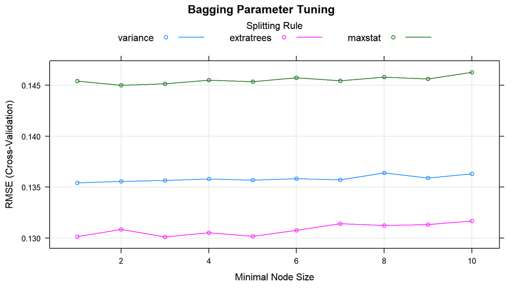

```r
plot(model.bag, main = "Bagging Parameter Tuning")
```

How does the model perform against the out-of-sample set?

```r
perf.bag <- postResample(
  pred = predict(model.bag, newdata = d.train20),
  obs = d.train20$logSalePrice
  )
perf.bag
```

```
##       RMSE   Rsquared        MAE
## 0.12628707 0.90381922 0.08659412
```

This is the worst model so far.

## Random Forest

Random forests improve bagged trees by way of a small tweak that de-correlates the trees. As in bagging, the algorithm builds a number of decision trees on bootstrapped training samples. But when building these decision trees, each time a split in a tree is considered, a random sample of *mtry* predictors is chosen as split candidates from the full set of *p* predictors. A fresh sample of *mtry* predictors is taken at each split. Typically $mtry \sim \sqrt{B}$. Bagged trees are thus a special case of random forests where *mtry = p*.

```r
model.for <- train(
  # pass in matrix instead of formula
  x = d.train80[, -1],
  y = d.train80[, 1],
  method = "ranger",
  metric = "RMSE",
  preProcess = c("zv"),
  tuneGrid = expand.grid(
    .mtry = seq(from = 50, to = 94, by = 5),  # mtry varies for random forest
    .splitrule = c("extratrees"),  # optimized out variance, maxstat
    .min.node.size = seq(from = 4, to = 5, by = 1)
  ),
  trControl = model.trControl
)
```

Here are the tuning results.

```r
model.for$bestTune
```

```
##    mtry  splitrule min.node.size
## 13   80 extratrees             4
```

Here is a plot of the tuning process for `mtry`, `splitrule`, and `min.node.size`.

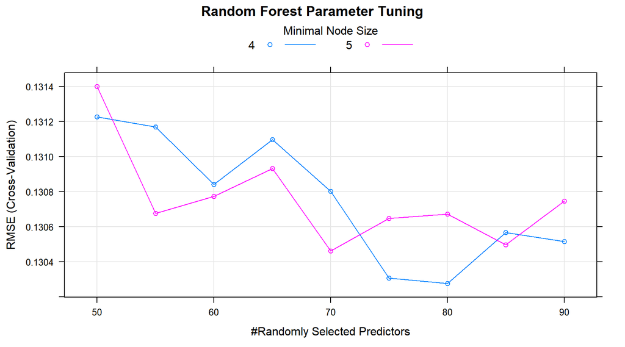

```r
plot(model.for, main = "Random Forest Parameter Tuning")
```

How does the model perform against the out-of-sample set?

```r
perf.for <- postResample(
  pred = predict(model.for, newdata = d.train20),
  obs = d.train20$logSalePrice
  )
perf.for
```

```
##       RMSE   Rsquared        MAE
## 0.12409761 0.90720940 0.08581021
```

A little better than bagging.

## Boosting

Boosting is a method to improve (boost) the week learners sequentially and increase the model accuracy with a combined model. The regression trees are addative, so that the successive models can be added together to correct the residuals in the earlier models. There are several boosting algorithms. One of the earliest was AdaBoost (adaptive boost). A more recent innovation is gradient boosting.

The gradient boosting algorithm fits a shallow tree $T_1$ to the data, $M_1 = T_1$. Then it fits a tree $T_2$ to the residuals and adds a weighted sum of the tree to the original tree as $M_2 = M_1 + \gamma T_2$. For regularized boosting, include a learning rate factor $\eta \in (0..1)$, $M_2 = M_1 + \eta \gamma T_2$. A larger $\eta$ produces faster learning, but risks overfitting. The process repeats until the residuals are small enough, or until it reaches the maximum iterations. Because overfitting is a risk, use cross-validation to select the appropriate number of trees (the number of trees producing the lowest RMSE).

It is common to constrain the weak learners by setting maximum tree size parameters.

**Tree Constraints**. In general the more constrained the tree, the more trees need to be grown. Parameters to optimize include number of trees, tree depth, number of nodes, minimum observations per split, and minimum improvement to loss.

**Learning Rate**. Each successive tree can be weighted to slow down the learning rate. Decreasing the learning rate increases the number of required trees. Common growth rates are 0.1 to 0.3.

```r
model.gbm <- train(
  # pass in matrix instead of formula
  x = d.train80[, -1],
  y = d.train80[, 1],
  method = "gbm",  # gradient boosting
  metric = "RMSE",
  distribution = "gaussian",
  verbose = FALSE,
  preProcess = c("zv"),
  tuneGrid = expand.grid(
    .n.trees = seq(from = 100, to = 400, by = 20),
    .interaction.depth = c(3, 4, 5),
    .shrinkage = c(0.025, 0.050, 0.075),  # aka, learning rate
    .n.minobsinnode = c(2, 3, 4)
  ),
  trControl = model.trControl
)
```

Here are the tuning results.

```r
model.gbm$bestTune
```

```
##     n.trees interaction.depth shrinkage n.minobsinnode
## 222     360                 4      0.05              3
```

Here is a plot of the tuning process. I tweaked the tuning grid to hone in on the minimum n.trees, interaction.depth, shrinkage, and n.minobsinnode.

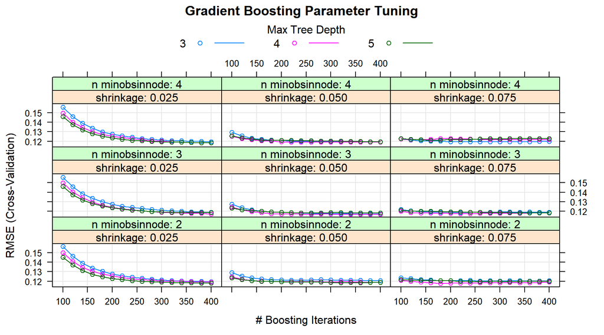

```r
plot(model.gbm, main = "Gradient Boosting Parameter Tuning")
```

How does the model perform against the out-of-sample set?

```r
perf.gbm <- postResample(
  pred = predict(model.gbm, newdata = d.train20),
  obs = d.train20$logSalePrice
)
perf.gbm
```

```
##      RMSE  Rsquared       MAE
## 0.1409272 0.9100788 0.1038152
```

# Nonlinear Regression

## MARS

Multivariate adaptive regression splines (MARS) is a non-parametric algorithm that creates a piecewise linear model to capture nonlinearities and interactions effects. The resulting model is a weighted sum of *basis* functions $B_i(X)$:

$$\hat{y} = \sum_{i=1}^{k}{w_iB_i(x)}$$

The basis functions are either a constant (for the intercept), a *hinge* function of the form $\max(0, x - x_0)$ or $\max(0, x_0 - x)$ (a more concise representation is $[\pm(x - x_0)]_+$), or products of two or more hinge functions (for interactions). MARS automatically selects which predictors to use and what predictor values to serve as the *knots* of the hinge functions.

MARS builds a model in two phases: the forward pass and the backward pass, similar to growing and pruning of tree models. MARS starts with a model consisting of just the intercept term equaling the mean of the response values. It then asseses every predictor to find a basis function pair consisting of opposing sides of a mirrored hinge function which produces the maximum improvement in the model error. MARS repeats the process until either it reaches a predefined limit of terms or the error improvement reaches a predefined limit. MARS generalizes the model by removing terms according to the generalized cross validation (GCV) criterion. GCV is a form of regularization: it trades off goodness-of-fit against model complexity.

The `earth::earth()` function ([documentation](https://www.rdocumentation.org/packages/earth/versions/5.1.2/topics/earth)) performs the MARS algorithm. The caret implementation tunes two parameters: `nprune` and `degree`. `nprune` is the maximum number of terms in the pruned model. `degree` is the maximum degree of interaction (default is 1 (no interactions)). However, there are other hyperparameters in the model that may improve performance, including `minspan` which regulates the number of knots in the predictors.

```r
mars_recipe <-
  recipe(logSalePrice ~ ., data = d.train80)

model.mars <- train(
  mars_recipe,
  data = d.train80,
  method = "earth",
  metric = "RMSE",
  minspan = -15,
  trControl = trainControl(method = "cv", number = 10),
  tuneGrid = expand.grid(
    degree = 1,
    nprune = seq(2, 100, length.out = 10) %>% floor()
  )
)
```

Here are the tuning results.

```r
model.mars$bestTune
```

```
##   nprune degree
## 4     34      1
```

Here is a plot of the tuning process. I tweaked the tuning grid to hone in on the best degree, nprune, and minspan.

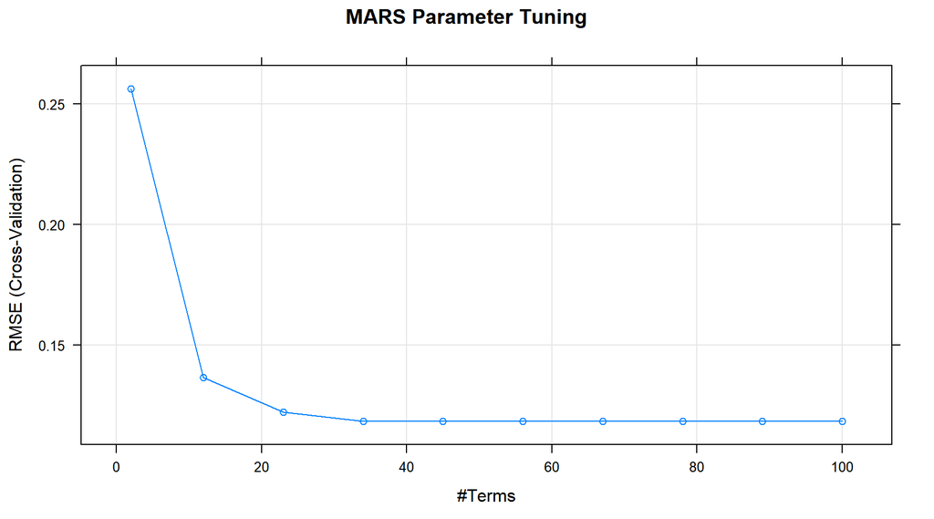

```r
plot(model.mars, main = "MARS Parameter Tuning")
```

How does the model perform against the out-of-sample set?

```r
(perf.mars <- postResample(
  pred = predict(model.mars, newdata = d.train20),
  obs = d.train20$logSalePrice
))
```

```
##       RMSE   Rsquared        MAE
## 0.10845481 0.92583481 0.07586015
```

Better than the tree models, but not as good as any of the penalization models.

# Model Evaluation

Here is a summary of the fitted model performances on the within-sample RMSE.

```r
models <- list(
  lm = model.lm,
  step = model.lmStepAIC,
  ridge = model.ridge,
  lasso = model.lasso,
  elnet = model.elnet,
  bag = model.bag,
  forest = model.for,
  gbm = model.gbm,
  mars = model.mars
  )
resamples(models) %>% summary(metric = "RMSE")
```

```
##
## Call:
## summary.resamples(object = ., metric = "RMSE")
##
## Models: lm, step, ridge, lasso, elnet, bag, forest, gbm, mars
## Number of resamples: 10
##
## RMSE
##              Min.    1st Qu.    Median      Mean   3rd Qu.      Max. NA's
## lm     0.08978350 0.09932232 0.1126135 0.1134890 0.1191586 0.1486381    0
## step   0.09190961 0.09867429 0.1094160 0.1118655 0.1169856 0.1483303    0
## ridge  0.09016751 0.11016887 0.1141998 0.1167755 0.1278078 0.1431738    0
## lasso  0.09042783 0.09803083 0.1076139 0.1113694 0.1220894 0.1374739    0
## elnet  0.08845663 0.09877814 0.1066840 0.1111543 0.1218575 0.1379346    0
## bag    0.11019638 0.11376123 0.1335396 0.1301196 0.1430998 0.1551429    0
## forest 0.11018524 0.11474932 0.1321038 0.1302770 0.1427174 0.1563838    0
## gbm    0.09208756 0.10530658 0.1187690 0.1167194 0.1296632 0.1433690    0
## mars   0.10291013 0.11060363 0.1142426 0.1184241 0.1216392 0.1451329    0
```

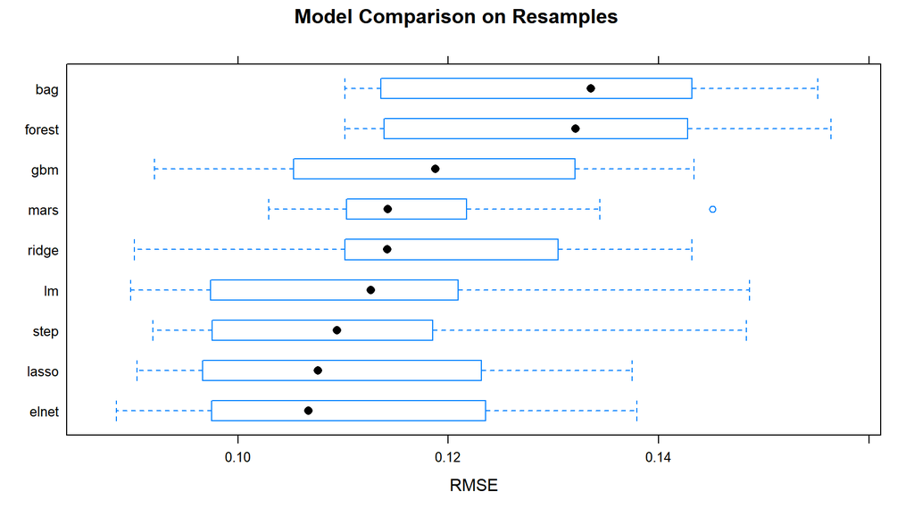

```r
bwplot(resamples(models), metric = "RMSE", main = "Model Comparison on Resamples")
```

And here is a summary of the fitted model performances on the out-of-sample RMSE.

```r
rbind(
  perf.lm,
  perf.step,
  perf.ridge,
  perf.lasso,
  perf.elnet,
  perf.bag,
  perf.for,
  perf.gbm,
  perf.mars
) %>% data.frame() %>% rownames_to_column(var = "Model") %>% arrange(-RMSE)
```

```
##        Model      RMSE  Rsquared        MAE
## 1   perf.gbm 0.1409272 0.9100788 0.10381516
## 2   perf.bag 0.1262871 0.9038192 0.08659412
## 3   perf.for 0.1240976 0.9072094 0.08581021
## 4  perf.step 0.1156460 0.9147938 0.07896297
## 5    perf.lm 0.1120078 0.9201101 0.07650913
## 6  perf.mars 0.1084548 0.9258348 0.07586015
## 7 perf.ridge 0.1067437 0.9276084 0.07701126
## 8 perf.lasso 0.1054827 0.9289183 0.07578788
## 9 perf.elnet 0.1041656 0.9309549 0.07458486
```

The big winner is… elastic net. Congratulations, elastic net!

# Fit Final Model

Elastic net was the winner, so I’ll use it to fit the final model for the competition submission using the full training data set.

```r
model.final <- train(
  logSalePrice ~ .,
  data = d.train[, !(colnames(d.train) %in% c("Id", "SalePrice"))],
  method = "glmnet",
  metric = "RMSE",
  preProcess = c("zv"),
  tuneGrid = expand.grid(
    .alpha = model.elnet$bestTune$alpha,
    .lambda = model.elnet$bestTune$lambda
  ),
  trControl = model.trControl
)

model.final
```

```
## glmnet
##
## 1450 samples
##   94 predictor
##
## Pre-processing: remove (13)
## Resampling: Cross-Validated (10 fold)
## Summary of sample sizes: 1045, 1045, 1045, 1045, 1044, 1044, ...
## Resampling results:
##
##   RMSE       Rsquared   MAE
##   0.1100634  0.9193564  0.07717383
##
## Tuning parameter 'alpha' was held constant at a value of 0.1388889
##
## Tuning parameter 'lambda' was held constant at a value of 0.02777778
```

# Create Submission File

The submission file is a csv file of Id and SalePrice.

```r
preds <- predict.train(model.final, newdata = d.test)
sub <- data.frame(Id = d.test$Id, SalePrice = exp(preds))
write.csv(sub, file = "./ames_03.csv", row.names = FALSE)
```